# MVA8

Sai Madhuri

2024-04-19

#DATASET :The Auto MPG dataset contains information about various car models and their fuel efficiency. It includes attributes such as cylinders, displacement, horsepower, weight, acceleration, model year, and origin. #1.mpg: Miles per gallon, the target variable representing fuel efficiency. #2.cylinders: Number of cylinders in the engine (typically 4, 6, or 8). #3.displacement: Engine displacement in cubic inches. #4.horsepower: Engine horsepower. #5.weight: Vehicle weight in pounds. #6.acceleration: Time taken for the vehicle to accelerate from 0 to 60 miles per hour (mph). #7.model year: Year of manufacturing (e.g., 70 for 1970, 71 for 1971, etc.). #8.origin: Origin of the car (1 for American, 2 for European, 3 for Japanese). #9.car name: Name of the car model.

```r
file_path <- "/Users/user/Downloads/auto-mpg.csv"
data <- read.csv(file_path)
autompg <- read.csv("/Users/user/Downloads/auto-mpg.csv")
str(autompg)
```

```
## 'data.frame':    398 obs. of  9 variables:
##  $ mpg         : num  18 15 18 16 17 15 14 14 14 15 ...
##  $ cylinders   : int  8 8 8 8 8 8 8 8 8 8 ...
##  $ displacement: num  307 350 318 304 302 429 454 440 455 390 ...
##  $ horsepower  : chr  "130" "165" "150" "150" ...
##  $ weight      : int  3504 3693 3436 3433 3449 4341 4354 4312 4425 3850 ...
##  $ acceleration: num  12 11.5 11 12 10.5 10 9 8.5 10 8.5 ...
##  $ model.year  : int  70 70 70 70 70 70 70 70 70 70 ...
##  $ origin      : int  1 1 1 1 1 1 1 1 1 1 ...
##  $ car.name    : chr  "chevrolet chevelle malibu" "buick skylark 320" "plymouth satellite" "amc rebel sst" ...
```

```r
autompg <- read.csv("/Users/user/Downloads/auto-mpg.csv")
autompg$horsepower <- as.integer(autompg$horsepower)
cleaned_auto <- na.omit(autompg)
str(autompg)
```

```
## 'data.frame':    398 obs. of  9 variables:
##  $ mpg         : num  18 15 18 16 17 15 14 14 14 15 ...
##  $ cylinders   : int  8 8 8 8 8 8 8 8 8 8 ...
##  $ displacement: num  307 350 318 304 302 429 454 440 455 390 ...
##  $ horsepower  : int  130 165 150 150 140 198 220 215 225 190 ...
##  $ weight      : int  3504 3693 3436 3433 3449 4341 4354 4312 4425 3850 ...
##  $ acceleration: num  12 11.5 11 12 10.5 10 9 8.5 10 8.5 ...
##  $ model.year  : int  70 70 70 70 70 70 70 70 70 70 ...
##  $ origin      : int  1 1 1 1 1 1 1 1 1 1 ...
##  $ car.name    : chr  "chevrolet chevelle malibu" "buick skylark 320" "plymouth satellite" "amc rebel sst" ...
```

```r
#Load required Libraries
library(dplyr)
library(tidyr)
library(MASS)
```

# Logistic Regression Analysis

### 1.Model Development

```r
# Create binary outcome variable: high mpg (1) vs. low mpg (0)
autompg <- autompg %>%
  mutate(new_mpg = ifelse(mpg > median(mpg), 1, 0))
```

```r
# Performing logistic regression on the dataset
logistic_simple <- glm(new_mpg ~ cylinders + displacement + horsepower + weight + acceleration, data = autompg, family = binomial)
```

#Considering the dependent variable mpg in binary format new_mpg and building the model with the independent variables namely cylinders,displacement,horsepower,weight and acceleration.

### 2.Model Acceptance

```r
summary(logistic_simple)
```

```
##
## Call:
## glm(formula = new_mpg ~ cylinders + displacement + horsepower +
##     weight + acceleration, family = binomial, data = autompg)
##
## Coefficients:
##                Estimate Std. Error z value Pr(>|z|)
## (Intercept)  13.6349642  2.7448448   4.967 6.78e-07 ***
## cylinders     0.0595333  0.3442526   0.173   0.8627
## displacement -0.0170756  0.0085887  -1.988   0.0468 *
## horsepower   -0.0562256  0.0204203  -2.753   0.0059 **
## weight       -0.0012639  0.0008601  -1.470   0.1417
## acceleration -0.1483927  0.1202479  -1.234   0.2172
## ---
## Signif. codes:  0 '***' 0.001 '**' 0.01 '*' 0.05 '.' 0.1 ' ' 1
##
## (Dispersion parameter for binomial family taken to be 1)
##
##     Null deviance: 542.60  on 391  degrees of freedom
## Residual deviance: 214.44  on 386  degrees of freedom
##   (6 observations deleted due to missingness)
## AIC: 226.44
##
## Number of Fisher Scoring iterations: 7
```

#The estimate column gives the coefficients that represent the log odds of the outcome variable (new_mpg) for one-unit increase in the predictor variable, holding other variables constant.

### 3.Residual Analysis

```r
residuals(logistic_simple)
```

[output not shown]

[output cut: 77 more lines]

[output not shown]

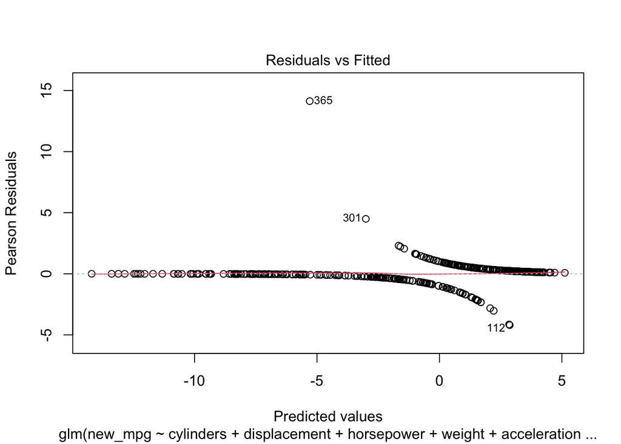

```r
plot(logistic_simple, which = 1)
```

#There is a fixed pattern in the residuals vs fitted plot which means that the selected independent variables will not explain the dependent variable well.

### 4.Prediction

```r
# Make predictions on the same dataset
predicted_values <- predict(logistic_simple, type = "response")
```

```r
# Convert predicted probabilities to binary predictions (0 or 1) based on a threshold 0.5
predicted_class <- ifelse(predicted_values > 0.5, 1, 0)
predicted_class
```

[output not shown]

[output cut: 25 more lines]

### 5.Accuracy

#we can compute accuracy by comparing predicted values with the original data

```r
original <- autompg$new_mpg  # Assuming new_mpg contains binary response variable (0 or 1)
accuracy <- mean(predicted_class == original)
print(accuracy)
```

```
## [1] 0.7160804
```

#Accuracy Provides an overall measure of model performance. An accuracy of 0.716 indicates that the logistic regression model correctly predicted the outcome (the value of new_mpg) approximately 71.6% correctly.

### Visualizations

```r
# Install pROC package (only need to run once)
#install.packages("pROC")

# Load the pROC package
library(pROC)
autompg$new_mpg
```

[output not shown]

```r
length(autompg$new_mpg)
```

```
## [1] 398
```

```r
length(predicted_class)
```

```
## [1] 392
```

```r
common <- intersect(seq_along(original), seq_along(predicted_class))
```

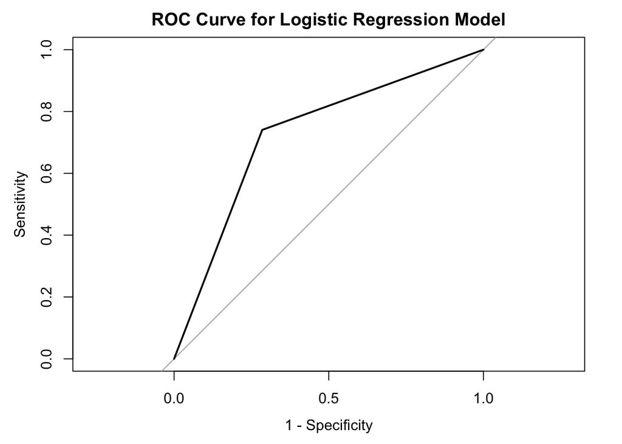

```r
# Compute ROC curve for the logistic regression model
roc_curve <- roc(original[common], predicted_class[common])
# Plot ROC curve
plot(roc_curve, legacy.axes = TRUE, main = "ROC Curve for Logistic Regression Model")
```

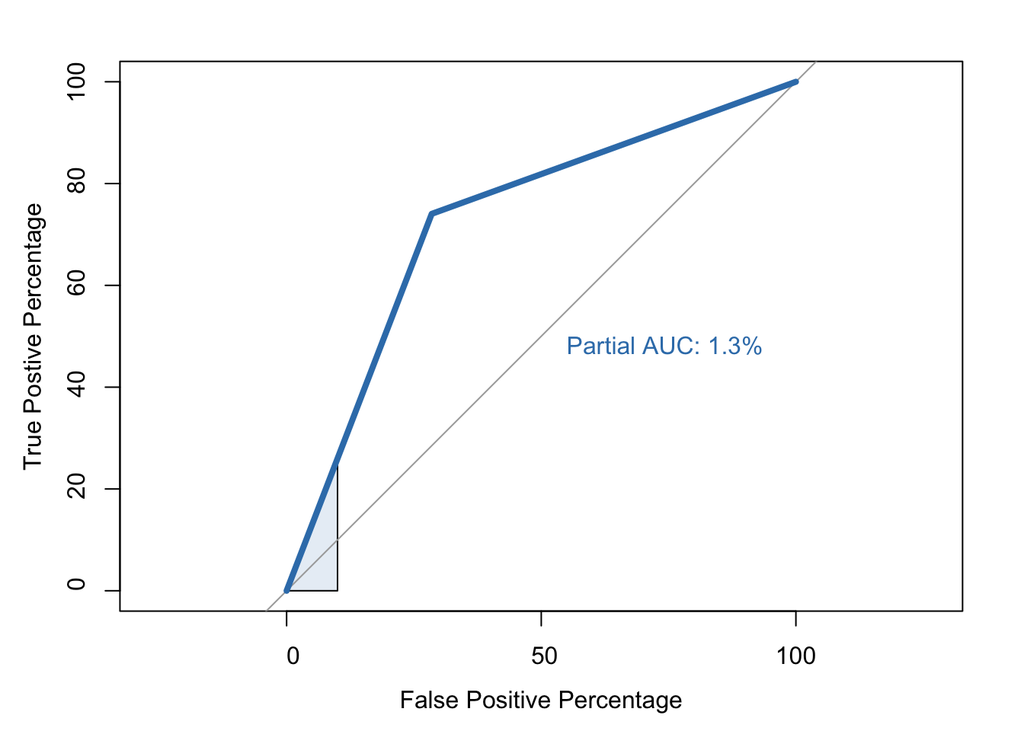

```
##
## Call:
## roc.default(response = original[common], predictor = predicted_class[common],     percent = TRUE, plot = TRUE, legacy.axes = TRUE, xlab = "False Positive Percentage",     ylab = "True Postive Percentage", col = "#377eb8", lwd = 4,     print.auc = TRUE, partial.auc = c(100, 90), auc.polygon = TRUE…
##
## Data: predicted_class[common] in 207 controls (original[common] 0) < 185 cases (original[common] 1).
## Partial area under the curve (specificity 100%-90%): 1.299%
```

```r
roc(original[common],predicted_class[common],plot=TRUE, legacy.axes=TRUE, xlab="False Positive Percentage", ylab="True Postive Percentage", col="#377eb8", lwd=4, percent=TRUE, print.auc=TRUE, partial.auc=c(100, 90), auc.polygon = TRUE, auc.polygon.col = "#377eb822", print.auc.x=45)
```